# Hierarchical Clustering - first

Chris coles

11 November 2015

Prep the data frame for the clustering exercise. Straight forward plot show groups of points that should show up in the clustering.

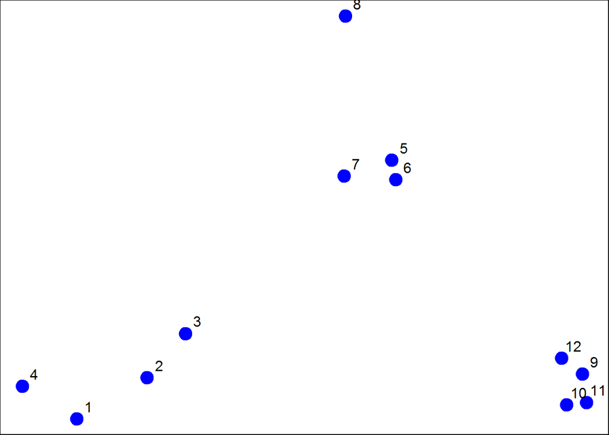

```r
set.seed(1234)
par(mar = c(0,0,0,0))
x <- rnorm(12, mean = rep(1:3, each = 4), sd = 0.2)
y <- rnorm(12, mean = rep(c(1,2,1), each = 4), sd = 0.2)
plot(x,y, col = "blue", pch = 19, cex = 2)
text(x + 0.05, y + 0.05, labels = as.character(1:12))
```

```r
myFrame <- data.frame(x=x, y=y)
print(myFrame)
```

```
##            x         y
## 1  0.7585869 0.8447492
## 2  1.0554858 1.0128918
## 3  1.2168882 1.1918988
## 4  0.5308605 0.9779429
## 5  2.0858249 1.8977981
## 6  2.1012112 1.8177609
## 7  1.8850520 1.8325657
## 8  1.8906736 2.4831670
## 9  2.8871096 1.0268176
## 10 2.8219924 0.9018628
## 11 2.9045615 0.9118904
## 12 2.8003227 1.0919179
```

The next calculation is the distance between each point in the plot. This is carried out by using the `dist()` function. This will produce an object of class dist that has a table of distances between each point.

```r
distXY <- dist(myFrame)
print(distXY)
```

```
##             1          2          3          4          5          6
## 2  0.34120511
## 3  0.57493739 0.24102750
## 4  0.26381786 0.52578819 0.71861759
## 5  1.69424700 1.35818182 1.11952883 1.80666768
## 6  1.65812902 1.31960442 1.08338841 1.78081321 0.08150268
## 7  1.49823399 1.16620981 0.92568723 1.60131659 0.21110433 0.21666557
## 8  1.99149025 1.69093111 1.45648906 2.02849490 0.61704200 0.69791931
## 9  2.13629539 1.83167669 1.67835968 2.35675598 1.18349654 1.11500116
## 10 2.06419586 1.76999236 1.63109790 2.29239480 1.23847877 1.16550201
## 11 2.14702468 1.85183204 1.71074417 2.37461984 1.28153948 1.21077373
## 12 2.05664233 1.74662555 1.58658782 2.27232243 1.07700974 1.00777231
##             7          8          9         10         11
## 2
## 3
## 4
## 5
## 6
## 7
## 8  0.65062566
## 9  1.28582631 1.76460709
## 10 1.32063059 1.83517785 0.14090406
## 11 1.37369662 1.86999431 0.11624471 0.08317570
## 12 1.17740375 1.66223814 0.10848966 0.19128645 0.20802789
```

From this we can see that the distance between point 1 and point 2 is 0.3412051 and between point 7 and point 4 it is 1.6013166. These distances are calculated using a the formula below with X and Y being the co ordinates of the poits. It is a imple equation that uses X and Y as two sides of a triangle and works out the direct line between the two points as the hyptonuse of the triangle - basic pythogourus theory. This is called the Euclidian distance.

The formula for calculating the Euclidian distnce between two points is :

$\sqrt{\left(X_1 - X_2\right)^2 + \left(Y_1 - Y_2\right)^2}$

The formula for calculating the Manhattan distance between two points is:

$\sum_{i=1}^{n} |p_i - q_i| = |p_1 - q_1| + |p_2 - q_2| + |p_3 - q_3|...$